# Predicting House Prices Using Multiple Regression

Group L17G03  
https://github.sydney.edu.au/aagg9744/L17G03

## 1. Aim and Approach

- Our aim is to determine which housing features are most strongly associated with differences in sale price.
- We explore the data to identify relevant predictors, then build and compare regression models to select a final model that is clear and interpretable.
- The dataset (*Housing_Prices_GE19*) contains **1,734 complete home sales** with **16 recorded features<sup>1</sup>**, and has no missing or invalid values, so we do not need any preprocessing or cleaning before analysis.
[^1]: Excluding Test attribute

## 2. Dataset Context & Considerations

- **Provenance:** The data provided is derived from Saratoga Housing Data (De Veaux). No other details (e.g. Region and time) were provided.
- **Assumptions:** Properties are treated as comparable sales from a single market context.
- **Biases & Risks:**
  - Local effects and condition are not captured and some variables are coarse (e.g. waterfront is Y/N, not quality)
  - Timing is absent. Results show *association* not causation

## 3. Overview of Data

- Living Area, Bathrooms and Land Value: Corr > 0.55.
- Multicollinearity will be considered

| Variable | Type | Distinct | mean | sd | median | IQR | min | max | Corr_with_Price |
| --- | --- | --- | --- | --- | --- | --- | --- | --- | --- |
| Price | numeric | 756 | $211,545.05 | $98,553.81 | $189,700.00 | $112,289.50 | $5,000.00 | $775,000.00 | 1.000 |
| Living.Area | numeric | 879 | 1752.63 | 620.22 | 1632.00 | 833.50 | 616.00 | 5228.00 | 0.713 |
| Bathrooms | numeric | 9 | 1.90 | 0.66 | 2.00 | 1.00 | 0.00 | 4.50 | 0.598 |
| Land.Value | numeric | 573 | $34,536.23 | $34,980.94 | $25,000.00 | $25,100.00 | $200.00 | $412,600.00 | 0.581 |
| Rooms | numeric | 11 | 7.03 | 2.32 | 7.00 | 3.00 | 2.00 | 12.00 | 0.533 |
| Bedrooms | numeric | 7 | 3.15 | 0.82 | 3.00 | 1.00 | 1.00 | 7.00 | 0.403 |
| Fireplaces | numeric | 5 | 0.60 | 0.56 | 1.00 | 1.00 | 0.00 | 4.00 | 0.380 |
| Pct.College | numeric | 32 | 55.57 | 10.32 | 57.00 | 12.00 | 20.00 | 82.00 | 0.200 |
| Lot.Size | numeric | 170 | 0.50 | 0.70 | 0.37 | 0.37 | 0.00 | 12.20 | 0.157 |
| Test | numeric | 2 | 0.25 | 0.43 | 0.00 | 0.75 | 0.00 | 1.00 | 0.009 |
| Age | numeric | 137 | 28.26 | 29.86 | 19.00 | 21.00 | 0.00 | 225.00 | -0.199 |
| Waterfront | logical | 2 | NA | NA | NA | NA | NA | NA | NA |
| New.Construct | logical | 2 | NA | NA | NA | NA | NA | NA | NA |
| Central.Air | logical | 2 | NA | NA | NA | NA | NA | NA | NA |
| Fuel.Type | character | 7 | NA | NA | NA | NA | NA | NA | NA |
| Heat.Type | character | 4 | NA | NA | NA | NA | NA | NA | NA |
| Sewer.Type | character | 3 | NA | NA | NA | NA | NA | NA | NA |

## 4. Variable Distribution & Correlation

Price is right-skewed → log-transform likely beneficial. Living Area, Bathrooms and Land Value have correlations (>0.55).

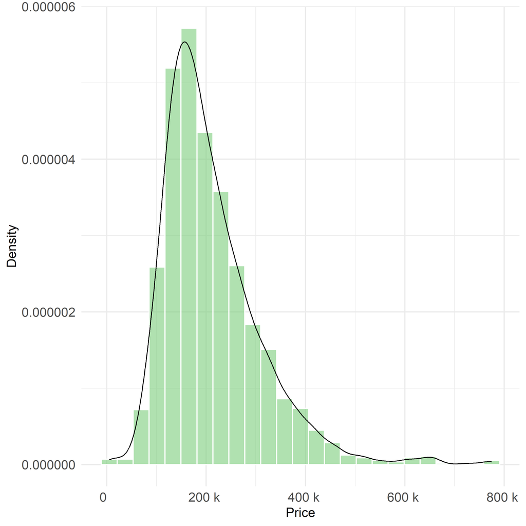

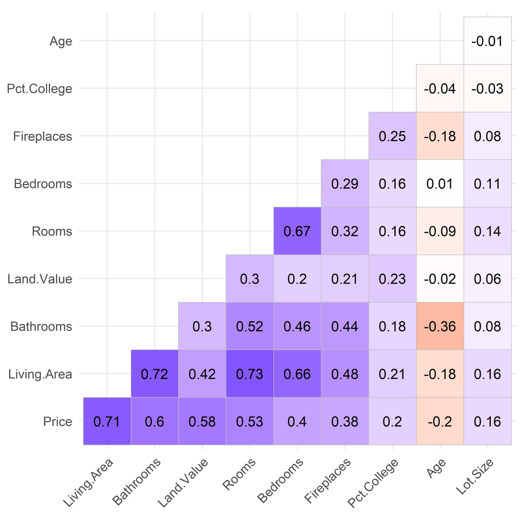

## 5. Exploratory Plots of Key Variables

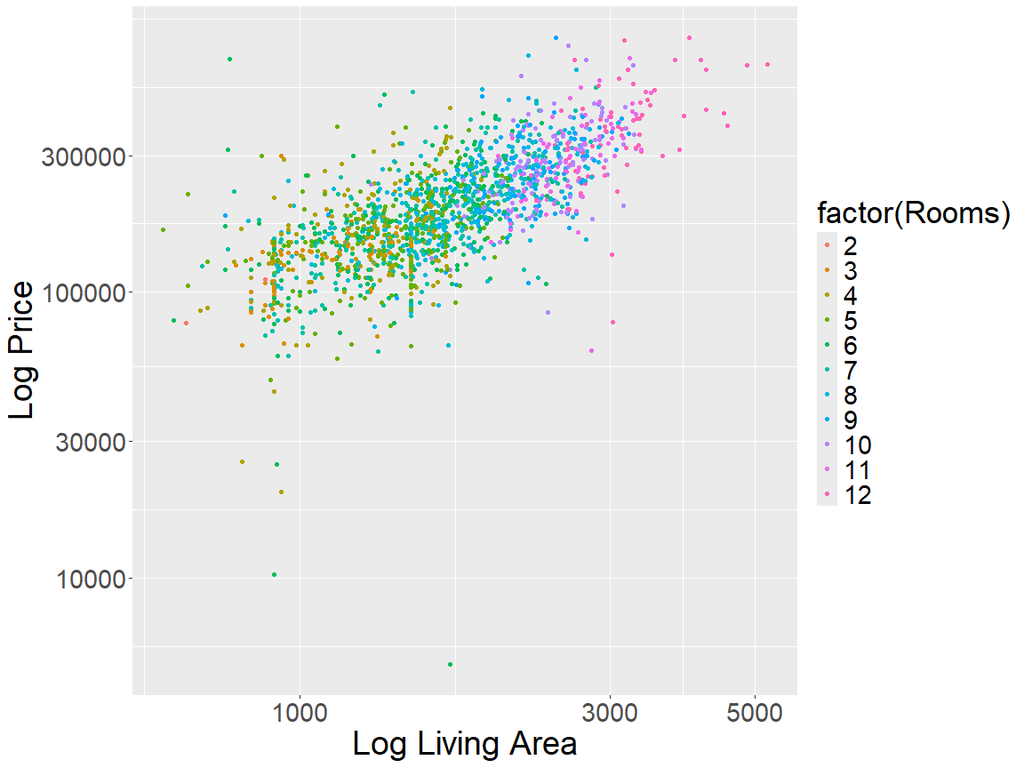

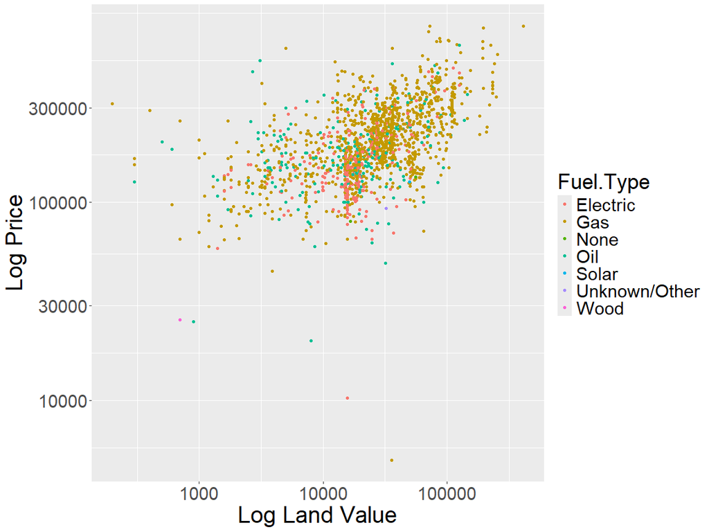

## 6. Ensuring a Reliable Regression Model

Regression models rely on several assumptions

Valid assumptions → accurate predictions & interpretations

Violations → biased or unreliable results

## 7. Core Regression Assumptions

Linearity: Predictors and outcome should have linear relationships.

Normality: Residuals should roughly follow a normal distribution.

Homoskedasticity: Residual variance should be constant.

Independence: Observations should not influence each other.

## 8. Feature Engineering

- **Log transformations:** applied to `Price`, `Living.Area`, `Lot.Size`, and `Land.Value` to reduce right-skew and stabilize variance.
- **Ratio variables:** `bath_per_bed`, `area_per_room`, and `coverage` capture **layout efficiency** independent of overall scale.
- **Land-intensity metrics:** (`land_per_area`, `land_per_lot`) quantify **land value per unit of built area**, serving as a proxy for **location scarcity**.
- **Winsorization (1st–99th pct):** limits the influence of extreme ratio values without discarding observations.
- **Categorical variables:** recoded into **binary dummy indicators** for inclusion in regression models.

| Variable | Example levels | Dummies (after coding) |
| --- | --- | --- |
| `Heat.Type` | Hot Air / Hot Water / Electric / None | `Heat.Type_Hot Air`, `Heat.Type_Hot Water`, `Heat.Type_Electric`, `Heat.Type_None` |
| `Fuel.Type` | Gas / Oil / Electric / Other | `Fuel.Type_Gas`, `Fuel.Type_Oil`, `Fuel.Type_Electric`, `Fuel.Type_Other` |
| `Sewer.Type` | Public / Private / None/Unknown | `Sewer.Type_Public`, `Sewer.Type_Private`, `Sewer.Type_None/Unknown` |

## 9. Model Design Stages & Rationale

1. **Baseline Linear Model (MLR)**
   - Includes core **structural** and **environmental** predictors, selected for strong or theoretically justified correlation with Price:  
     `ln_living`, `ln_lot`, `Age`, `fireplace_bin`, `pct_college`, `Waterfront`, `Central.Air`, and heating/fuel/sewer dummies.
   - Captures the fundamental relationship between these factors and the **log-transformed Price**.
   - Adjusted R² ≈ **0.51**.
2. **Extended Linear Model**
   - Adds engineered **layout** and **land-intensity** features:  
     `bath_per_bed_clip`, `area_per_room_clip`, `bed_share_clip`, `coverage_clip`, `land_per_area_clip`.
   - Improves explanatory power → Adjusted R² ≈ **0.59**.
   - Captures differences in **spatial efficiency** (layout) and **land-use quality** (location value).
3. **Stepwise AIC Model**
   - Forward and backward AIC procedures converge to the same ten predictors (AIC = **435.2**).
   - Achieves strong fit with Adjusted R² ≈ **0.60** and RMSE ≈ **0.28**.
   - Ensures the final model remains **parsimonious yet accurate**.

## 10. Model Fitting & Diagnostics

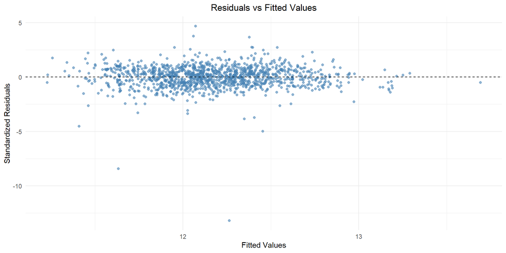

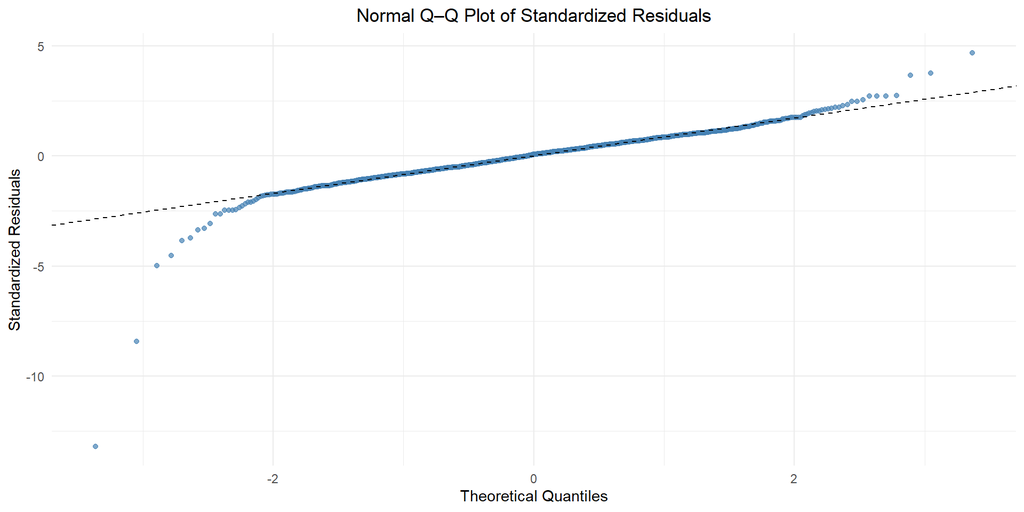

**Model Diagnostics (Stepwise AIC Model)**

## 11. Model Comparison

|  | Forward model |  | Backward model |  |
| --- | --- | --- | --- | --- |
| Predictors | Estimates | p | Estimates | p |
| (Intercept) | 5.37 | **<0.001** | 5.37 | **<0.001** |
| ln living | 0.87 | **<0.001** | 0.87 | **<0.001** |
| land per area clip | 0.01 | **<0.001** | 0.01 | **<0.001** |
| Age | -0.00 | **<0.001** | -0.00 | **<0.001** |
| Waterfront | 0.48 | **<0.001** | 0.48 | **<0.001** |
| ln lot | 0.19 | **<0.001** | 0.19 | **<0.001** |
| bath per bed clip | 0.27 | **<0.001** | 0.27 | **<0.001** |
| coverage clip | 0.00 | **0.004** | 0.00 | **0.004** |
| area per room clip | -0.00 | **<0.001** | -0.00 | **<0.001** |
| bed share clip | 0.34 | **0.002** | 0.34 | **0.002** |
| Heat Type Hot Air | 0.04 | **0.022** | 0.04 | **0.022** |
| Observations | 1300 |  | 1300 |  |
| R<sup>2</sup> / R<sup>2</sup> adjusted | 0.598 / 0.595 |  | 0.598 / 0.595 |  |
| AIC | 435.225 |  | 435.225 |  |

**Comparison Summary**

- Both forward and backward AIC procedures converged to **the same 10 predictors**.
- **ΔAIC = 0**, meaning the two models are statistically equivalent.
- Final model achieves **Adjusted R² ≈ 0.60, AIC ≈ 435.2,** indicating a strong overall fit.
- The chosen model balances **parsimony** (few variables) and **predictive accuracy**.

## 12. Recommended Model

The final model selected via **Stepwise AIC**, explains the variation in **log(Price)** using structural, efficiency, and land-intensity predictors.

$${\small
\begin{aligned}
\log(\text{Price}) =\;&
5.372843
+ 0.868127 \times \text{ln_living}
+ 0.008552 × \,\text{land_per_area_clip}\\&
- 0.00134 × \,\text{Age}
+ 0.484149 × \,\text{Waterfront}\\
&
+ 0.187077 × \,\text{ln_lot}
+ 0.268309 × \,\text{bath_per_bed_clip} \\
&
+ 0.000002 × \,\text{coverage_clip}
- 0.00083 × \,\text{area_per_room_clip} \\
&
+ 0.341946 × \,\text{bed_share_clip}
+ 0.038835 × \,\text{Heat.Type_Hot Air}
\end{aligned}
}$$

**Interpretation:**  
Each coefficient represents the proportional effect on **log(Price)**, holding other variables constant.

## 13. Model Interpretation

**Key Effects on log(Price)**

- **Intercept:** Represents the baseline log(Price) when all predictors are at their reference levels.
- **ln_living:** Measures the elasticity of price with respect to living area. Larger homes are associated with higher log(Price).
- **ln_lot:** Captures the influence of total land size. Larger lots tend to increase log(Price), although the effect is smaller than that of living area.
- **Age:** Has a negative coefficient, indicating that older houses generally have lower log(Price).
- **Waterfront:** Adds a strong positive premium, showing that location substantially affects house values.
- **bath_per_bed_clip** and **bed_share_clip:** Reflect layout efficiency. Houses with more balanced room and bathroom proportions are linked to higher log(Price).
- **area_per_room_clip:** Slightly negative, suggesting that excessively large rooms reduce overall efficiency and lower log(Price).
- **coverage_clip:** Represents land-use intensity. Moderate coverage levels are associated with higher log(Price).
- **land_per_area_clip:** Indicates land value relative to built area. Higher ratios correspond to more valuable or efficiently utilized land.
- **Heat.Type_Hot Air:** Shows a small positive effect, possibly reflecting the appeal of modern heating systems.

## 14. Model Validation & Performance Assessment

- **Cross-validation results:**  
  RMSE = 0.279; MAE = 0.204.  
  Cross-validation confirms stable predictive accuracy and low variance across folds.
- **Test set performance:** RMSE = 0.304; MAE = 0.217.  
  Out-of-sample results are consistent with cross-validation, confirming strong generalization and minimal overfitting.  
  An RMSE of around 0.30 implies predictions are typically within ±35% of actual prices on the log scale, while the MAE corresponds to an average ±24% deviation.

Together, these metrics show that the model achieves a good balance between predictive accuracy and interpretability.